# Kyphosis

## Example

```r
library(rpart)
library(rpart.plot)
head(kyphosis)
```

```
  Kyphosis Age Number Start
1   absent  71      3     5
2   absent 158      3    14
3  present 128      4     5
4   absent   2      5     1
5   absent   1      4    15
6   absent   1      2    16
```

```r
source("cost_complexity_measure.R")
```

```r
node.fun.class.dev <- function(x, labs, digits, varlen) {
  stats <- get.class.stats(x)
  paste(stats$ylevels[1], stats$ylevels[2], "\n", stats$n.per.lev[,1], "      ", stats$n.per.lev[,2],
        "\ndev: ", x$frame$dev)
}

node.fun.gt <- function(x, labs, digits, varlen) {
  paste("g(t):", round(x$frame$gt, 2))
}

node.fun.gt.calc <- function(x, labs, digits, varlen) x$frame$label

node.label <- function(x, labs, digits, varlen) x$frame$label

node.fun.cp <- function(x, labs, digits, varlen) {
  paste("dev:", x$frame$dev, "\ncp:", round(x$frame$complexity, 3))
}

node.fun.cp.gt <- function(x, labs, digits, varlen) {
  if_else(x$frame$var != "<leaf>",
  paste("g(t):", round(x$frame$gt, 2), "\ncp:", round(x$frame$complexity, 2)), "leaf")
}

split.order <- function(x, labs, digits, varlen) {
  l <- label_as_integer(x$frame$var)
  ifelse(l == "<leaf>", "leaf", paste0("split #", l))
}

split.order.dev <- function(x, labs, digits, varlen) {
  l <- label_as_integer(x$frame$var)
  l <- ifelse(l == "<leaf>", "leaf", paste0("split #", l))
  paste(l, "\ndev: ", x$frame$dev)
}
```

`Kyphosis` – type of deformation `absent` or `present` after surgery

`Age` – in months

`Number` – the number of vertebrae involved

`Start` – the number of the first (topmost) vertebra operated on

## Gini index

With no splits,

$p_1$ = 64/81, $1 - p_1$ = 17/81

$p_2$ = 17/81, $1 - p_2$ = 64/81

$\Sigma_{k=1}^K \hat{p}_{mk}(1-\hat{p}_{mk}) =$

$\frac{64}{81} \cdot \frac{17}{81} + \frac{17}{81} \cdot \frac{64}{81} = .332$

## After one split

Impurity of node #2:

$\frac{56}{62} \cdot \frac{6}{62} + \frac{6}{62} \cdot \frac{56}{62} = .175$

Impurity of node #3:

$\frac{8}{19} \cdot \frac{11}{19} + \frac{11}{19} \cdot \frac{8}{19} = .488$

Total impurity is weighted by $n$:

$\frac{62}{81} \cdot .175 + \frac{19}{81} \cdot .488 = .248$

Impurity reduction:

$.332 - .248 = .084$

This split is chosen since it maximizes impurity reduction.

## Growing the tree

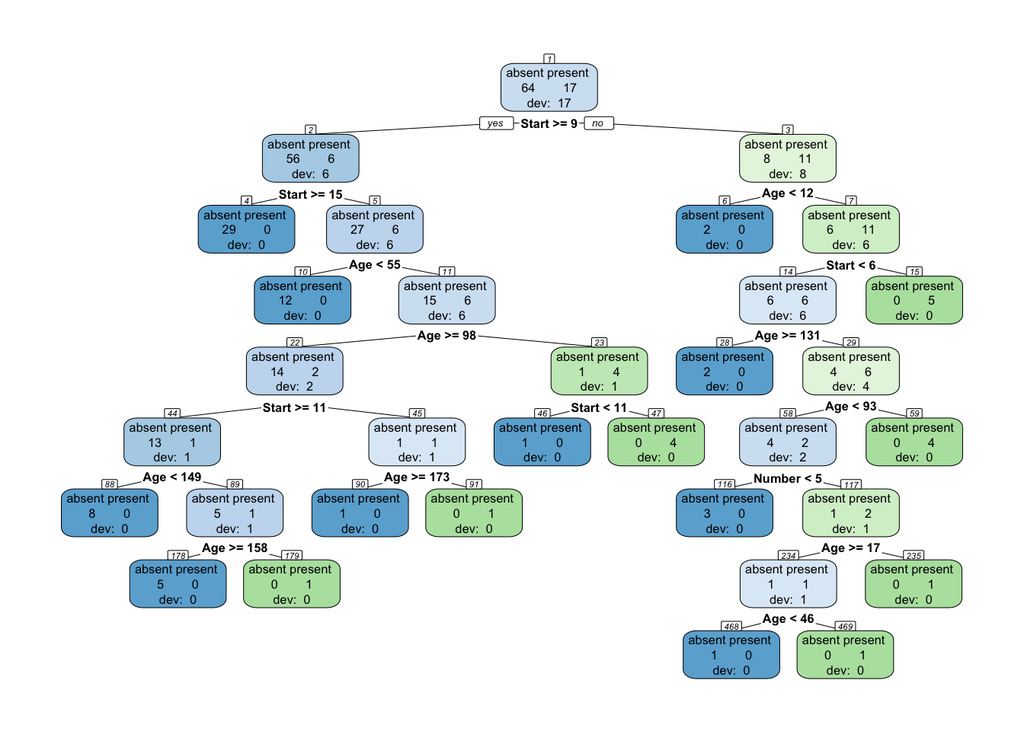

```r
kmod1 <- rpart(Kyphosis ~ Age + Number + Start,
              data = kyphosis, cp = 0, minbucket = 1,
              minsplit = 1)
kmod <- kmod1

node.fun.class <- function(x, labs, digits, varlen) {
  stats <- get.class.stats(x)
  paste(stats$ylevels[1], stats$ylevels[2], "\n", stats$n.per.lev[,1], "      ", stats$n.per.lev[,2])
}

prp(kmod, extra = 1, type = 2,node.fun = node.fun.class.dev,
    nn = TRUE, box.palette = "auto")
```

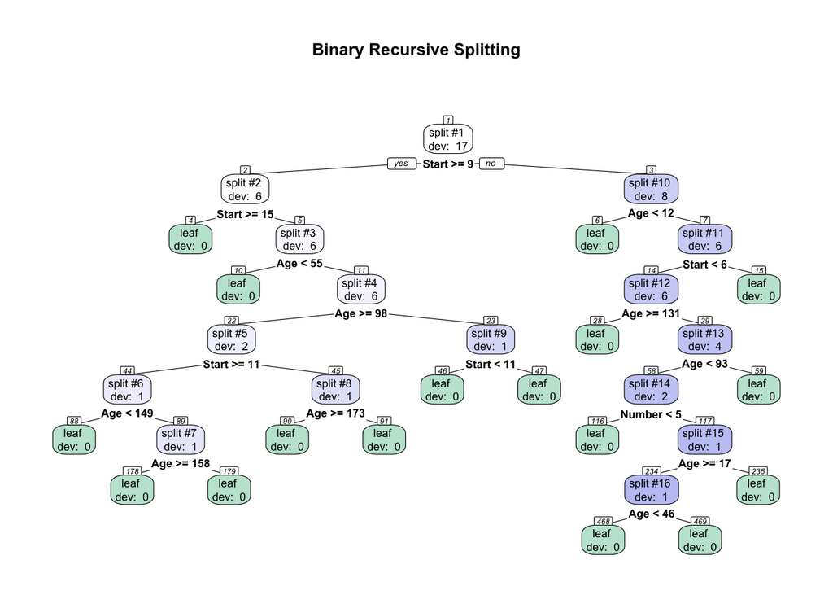

```r
colors <- vector_colors(1:nrow(kmod$frame), "white", "#B6BCF1")

colors[kmod$frame$var == "<leaf>"] <- "#00A86B50"

#prp(kmod, extra = 1, type = 2,node.fun = split.order,
 #   nn = TRUE, box.col = colors)

prp(kmod, extra = 1, type = 2,node.fun = split.order.dev,
    nn = TRUE, box.col = colors,
    main = "Binary Recursive Splitting")
```

```r
splitorder <- as.numeric(rownames(kmod$frame)[kmod$frame$var != "<leaf>"])
```

Split order by node: 1, 2, 5, 11, 22, 44, 89, 45, 23, 3, 7, 14, 29, 58, 117, 234

Since we set `cp = 0` we know that the tree will have 16 splits.

This information is captured in the last line of the `cptable` returned from `rpart`:

```r
tail(kmod$cptable, 1)
```

```
  CP nsplit rel error   xerror      xstd
6  0     16         0 1.235294 0.2320031
```

Now we will find the minimum complexity parameter needed to prune any nodes of the tree. To do so we use a method called minimum cost complexity pruning, which looks for the weakest link, defined as the split which renders the smallest reduction in some function g(t).

## Pruning the tree

For pruning purposes, **rpart** uses the misclassification rate, not the Gini index.

Every split in the large tree is evaluated for the reduction in misclassified cases (deviance) *per split*.

Now let’s find the deviance reduction per node for all splits:

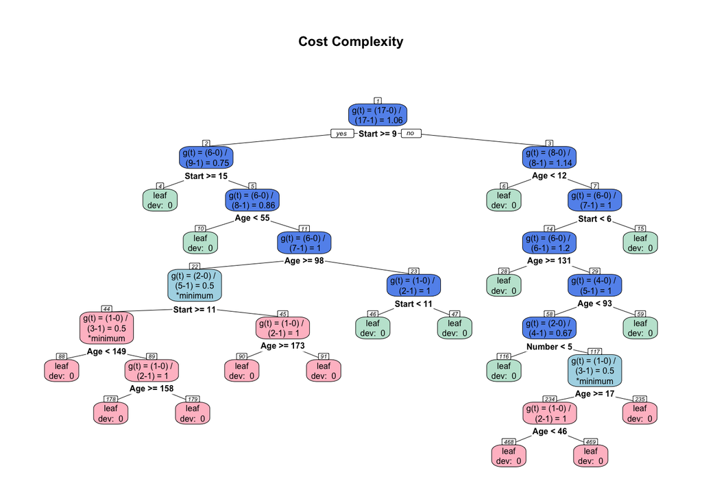

```r
library(tidyverse)
kmod$frame <- annotate_gt(kmod)

kmod$frame$nn <- as.numeric(rownames(kmod$frame))


get_descendants <- function(node, all_nodes) {
    # Recursive function to collect all descendants
    children <- c(2 * node, 2 * node + 1)
    descendants <- children[children %in% all_nodes]
    for (child in descendants) {
        descendants <- c(descendants, get_descendants(child, all_nodes))
    }
    return(descendants)
}


gt_calc_colors <- function(mod) {
  if (nrow(mod$frame) == 1) {
    "#00A86B50"
  } else {
    mingt <- min(mod$frame$gt, na.rm = TRUE)
    mingt_nodes <- na.omit(mod$frame$nn[mod$frame$gt == mingt])
    mingt_node_cp <- mod$frame$complexity[mod$frame$nn == mingt_nodes][1]
    to_be_pruned <- unique(unlist(
      lapply(mingt_nodes, get_descendants, all_nodes = mod$frame$nn)
    ))
    case_when(
      mod$frame$nn %in% to_be_pruned ~ "pink",
      mod$frame$gt == mingt ~ "lightblue",
      !is.na(mod$frame$gt) ~ "cornflowerblue",
      .default = "#00A86B50"
    )
  }
}

gt_calc_label <- function(mod) {
  if (nrow(mod$frame) == 1) {
    paste("   leaf   \ndev: ", mod$frame$dev)
  } else {
    mingt <- min(mod$frame$gt, na.rm = TRUE)
    label <- ifelse(
      mod$frame$var != "<leaf>",
      paste0("g(t) = (", mod$frame$dev, "-",
             mod$frame$subdev, ") / \n (",
             mod$frame$numsplits, "-1) = ",
             round(mod$frame$gt, 2)),
      paste("   leaf   \ndev: ", mod$frame$dev)
    )
    label <- case_when(mod$frame$gt == mingt ~ paste(label, "\n*minimum"),
                       .default = label)
    label
  }
}

kmod$frame$label <- gt_calc_label(kmod)
colors <- gt_calc_colors(kmod)


prp(kmod, extra = 1, type = 2,
    node.fun = node.label,
    nn = TRUE, box.col = colors,
    main = "Cost Complexity")
```

We have discovered that a tree with cp > 0.02941176 will have 10 splits:

```r
tail(kmod$cptable, 2)
```

```
          CP nsplit rel error   xerror      xstd
5 0.02941176     10 0.1764706 1.117647 0.2243268
6 0.00000000     16 0.0000000 1.235294 0.2320031
```

Now we need to recalculate g(t) for the pruned tree:

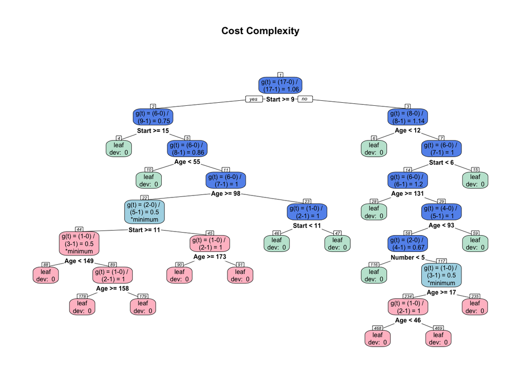

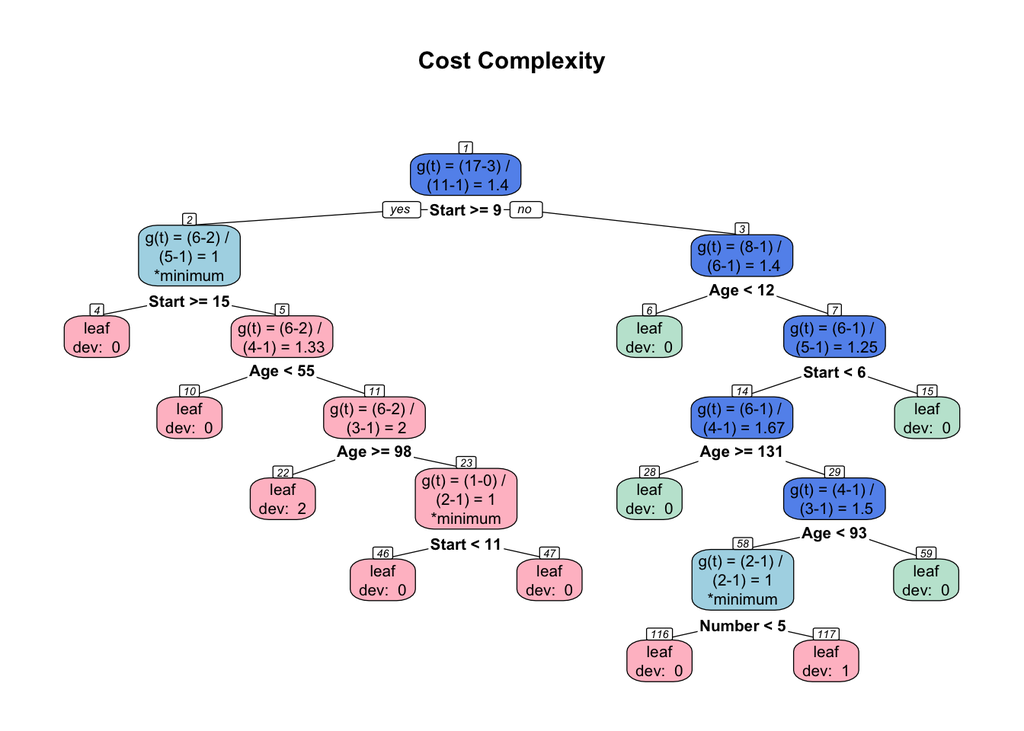

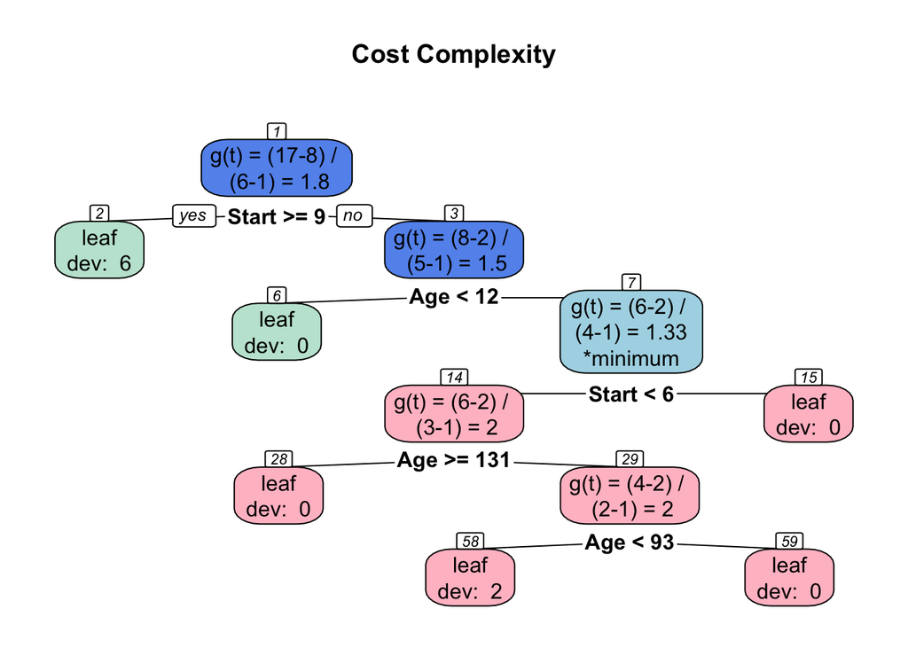

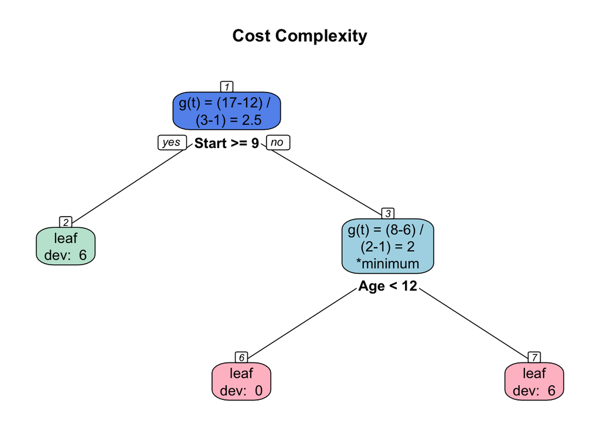

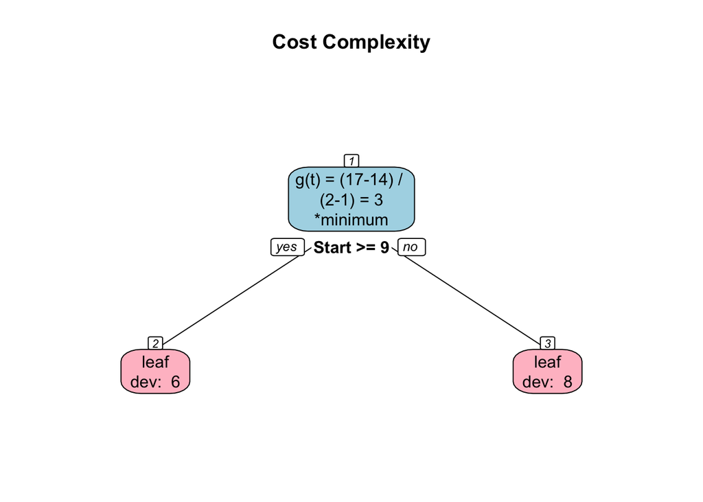

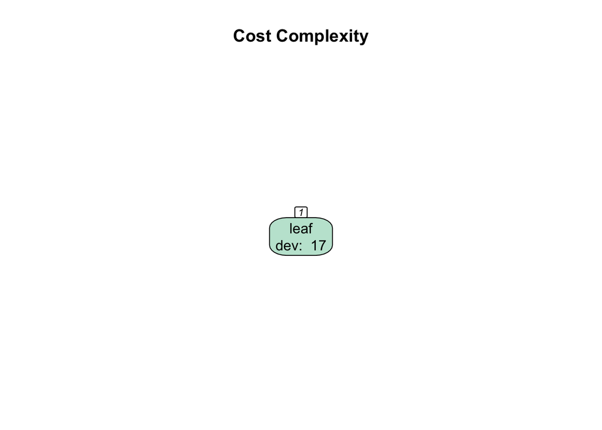

```r
n <- nrow(kmod$cptable)
for (i in n:1) {
  kmod <- prune(kmod, kmod$cptable[i])
  kmod$frame <- annotate_gt(kmod)
  kmod$frame$nn <- as.numeric(rownames(kmod$frame))
  colors <- gt_calc_colors(kmod)
  kmod$frame$label <- gt_calc_label(kmod)
  prp(kmod, extra = 1, type = 2,
    node.fun = node.fun.gt.calc,
    nn = TRUE, box.col = colors,
    main = "Cost Complexity")
  }
```